# WGCNA in Proteomic data. Shared proteins norm

# 1 Data input, cleaning and pre-processing

Load protein abundance data, pre-process them into a format suitable for network analysis, and clean the data by removing obvious outlier samples as well as proteins and samples with excessive numbers of missing entries.

## 1.a Loading expression data

The expression data is contained in the file:

- 1-9_A1_A2_A3__precol2cm_col75cm_top15_70000_3e6_50_35000_5e4_100_iw4_excl40_2h_200nlmin_1ul_A1vsA2vsA3.xlsx that comes with this tutorial.
- 10-14_C1_C2_C3__precol2cm_col75cm_top15_70000_3e6_50_35000_5e4_100_iw4_excl40_2h_200nlmin_1ul_C1vsC2vsC3.xlsx
- 1-14_A1_A2_A3_C1_C2_C3_precol2cm_col75cm_top15_70000_3e6_50_35000_5e4_100_iw4_excl40_2h_200nlmin_1ul_AvsC_abundances_indiv: Contains protein abundance in both groups.

Files grouped by samples, not share same proteins. This is one important point to discuss. One aporximation is consider missing protein with 0 abundance. Also it can be considered only the shared proetins.

```r
library(readxl)

# Load the WGCNA package
library(WGCNA)
# The following setting is important, do not omit.
options(stringsAsFactors = FALSE)
# Read in the female liver data set
pheno <- read_excel("./nomenclatura.xlsx")
# Take a quick look at what is in the data set:

# load("RESULTATS/OBJECTES/data_abundance")
data_abundance_raw <- read_xlsx("./Gener/1-14_A1_A2_A3_C1_C2_C3_precol2cm_col75cm_top15_70000_3e6_50_35000_5e4_100_iw4_excl40_2h_200nlmin_1ul_AvsC_abundances_indiv(1).xlsx")
dim(data_abundance_raw)
```

```
## [1] 1183  114
```

```r
data_abundance_raw_1 <- (data_abundance_raw)[grep("Abundances [(]Normalized)", colnames(data_abundance_raw))]
dim(data_abundance_raw_1)
```

```
## [1] 1183   28
```

```r
# data_abundance_raw_1 Aquesta matriu la fare servir per el WGCNA
data_abundance_raw_1 <- data.frame(data_abundance_raw_1)
rownames(data_abundance_raw_1) <- data_abundance_raw$Accession

# Arreglar els noms de les mostres

colnames(data_abundance_raw_1) <- gsub("Abundances..Normalized...", "", colnames(data_abundance_raw_1))
colnames(data_abundance_raw_1) <- gsub("..precipitation..EVs..n.a..1..1..", "", colnames(data_abundance_raw_1))
colnames(data_abundance_raw_1) <- gsub("..precipitation..EVs..n.a..1..2..", "", colnames(data_abundance_raw_1))
colnames(data_abundance_raw_1) <- gsub("..precipitation..EVs..n.a..2..1..", "", colnames(data_abundance_raw_1))
colnames(data_abundance_raw_1) <- gsub("..precipitation..EVs..n.a..2..2..", "", colnames(data_abundance_raw_1))
colnames(data_abundance_raw_1) <- gsub("..precipitation..EVs..n.a..3..1..", "", colnames(data_abundance_raw_1))
colnames(data_abundance_raw_1) <- gsub("..precipitation..EVs..n.a..3..2..", "", colnames(data_abundance_raw_1))
colnames(data_abundance_raw_1) <- gsub(".Sample..", "", colnames(data_abundance_raw_1))
colnames(data_abundance_raw_1) <- gsub("[.]", "_", colnames(data_abundance_raw_1))
data_abundance_raw_1 <- data_abundance_raw_1[, -grep("F65", colnames(data_abundance_raw_1))]
data_abundance_raw_1 <- data_abundance_raw_1[, -grep("F66", colnames(data_abundance_raw_1))]
dim(data_abundance_raw_1)
```

```
## [1] 1183   26
```

```r
pheno <- data.frame(name = colnames(data_abundance_raw_1))
pheno$Sample <- NA
pheno$Group <- NA
pheno <- read.csv("20240118-data(1).csv")

pheno <- pheno[-grep("F65", pheno$name), ]
pheno <- pheno[-grep("F66", pheno$name), ]
pheno$Sample_ID <- unlist(lapply(pheno$name, function(x) strsplit(x, "_")[[1]][1]))
dim(pheno)
```

```
## [1] 26  5
```

```r
# Hi ha NA. Substituir per 0.01
table(is.na(data_abundance_raw_1))
```

```
##
## FALSE  TRUE
## 30212   546
```

```r
data_abundance_raw_1[is.na(data_abundance_raw_1)] <- 0.01

datExpr0 <- as.data.frame(data_abundance_raw_1)


rownames(datExpr0) <- rownames(datExpr0)

# datExpr0<-datExpr0[,-1]
datExpr0 <- t(datExpr0)
```

## 1.b Checking data for excessive missing values and identification of outlier microarray samples

We first check for proteins and samples with too many missing values:

```r
gsg <- goodSamplesGenes(datExpr0, verbose = 3)
```

```
##  Flagging genes and samples with too many missing values...
##   ..step 1
##   ..Excluding 21 genes from the calculation due to too many missing samples or zero variance.
##   ..step 2
```

```r
gsg$allOK
```

```
## [1] FALSE
```

```r
if (!gsg$allOK) {
  # Optionally, print the gene and sample names that were removed:
  if (sum(!gsg$goodGenes) > 0) {
    printFlush(paste("Removing genes:", paste(colnames(datExpr0)[!gsg$goodGenes], collapse = ", ")))
  }
  if (sum(!gsg$goodSamples) > 0) {
    printFlush(paste("Removing samples:", paste(rownames(datExpr0)[!gsg$goodSamples], collapse = ", ")))
  }
  # Remove the offending genes and samples from the data:
  datExpr0 <- datExpr0[gsg$goodSamples, gsg$goodGenes]
}
```

```
## Removing genes: O15173, Q9Y4G6, Q9P2T1, Q7Z4I7, P06493, Q6ZU15, P0DPH8
## P0DPH7, P0CG38, P50993, P11217, P0CG39, P62745, P12036, P08670, Q5VST9, Q5T0T0, P68133, Q9NYU2, Q12840, Q8NF91, Q6A162
```

Next we cluster the samples (in contrast to clustering proteins that will come later) to see if there are any obvious outliers.

```r
dim(datExpr0)
```

```
## [1]   26 1162
```

```r
sampleTree <- hclust(dist(datExpr0), method = "average")
par(cex = 0.6)
par(mar = c(0, 4, 2, 0))
names(sampleTree)
```

```
## [1] "merge"       "height"      "order"       "labels"      "method"
## [6] "call"        "dist.method"
```

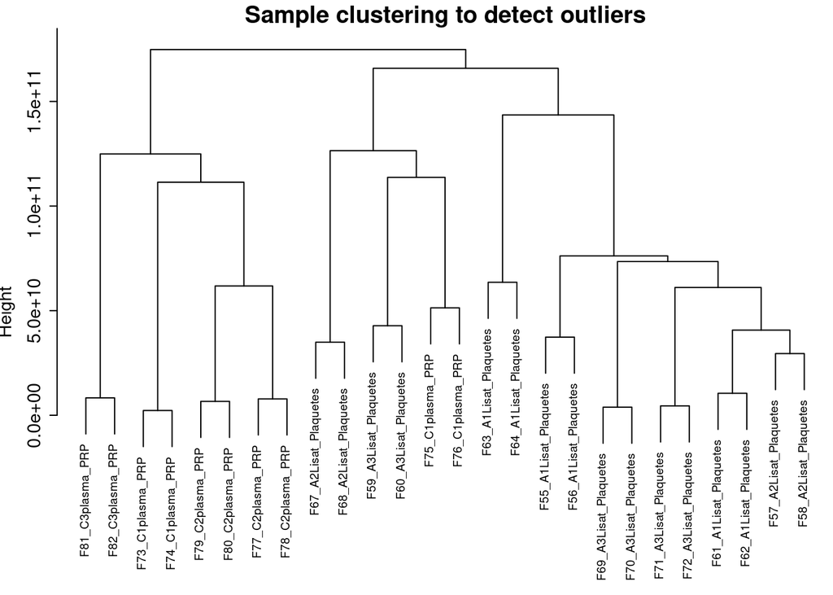

```r
plot(sampleTree,
  main = "Sample clustering to detect outliers", sub = "", xlab = "", cex.lab = 1.5,
  cex.axis = 1.5, cex.main = 2
)
```

La mostra A2 (F65 i F66 ) semblen outliers. Ja estan eliminades.

## 1.c Loading clinical trait data

```r
# Create datTraits
allTraits <- data.frame(pheno)

nameSamples <- rownames(datExpr0)
datTraits <- data.frame(name = nameSamples)
# PL-EV1 -> llista de plaquetes ->NaCL

datTraits$nom_uni <- datTraits$name

# datTraits$nom_uni[grep("Lisat.Plaquetes",datTraits$name)]<-"NaCl"

traitRows <- match(nameSamples, allTraits$name)
datTraits <- allTraits[traitRows, ]
rownames(datTraits) <- allTraits[traitRows, 1]
collectGarbage()
```

We now have the expression data in the variable datExpr, and the corresponding clinical traits in the variable datTraits.

## Sample dendrogram

Before we continue with network construction and module detection, we visualize how the clinical traits relate to the sample dendrogram

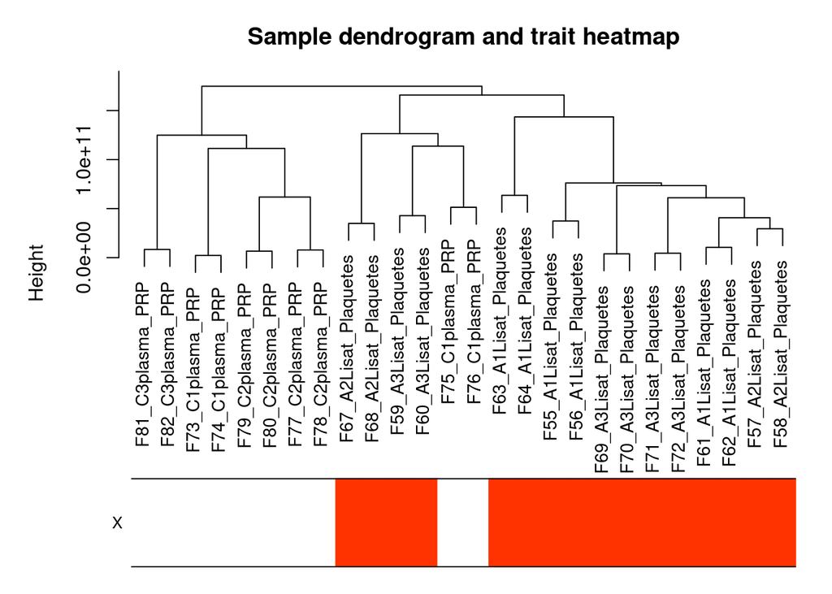

```r
# Re-cluster samples
sampleTree2 <- hclust(dist(datExpr0), method = "average")
# Convert traits to a color representation: white means low, red means high, grey means missing entry

datTraits$Group_num <- datTraits$Group
datTraits$Group_num <- gsub("NaCl", 1, datTraits$Group_num)
datTraits$Group_num <- gsub("PRP", 0, datTraits$Group_num)
traitColors <- numbers2colors(as.numeric(datTraits$Group_num), signed = FALSE)
# Plot the sample dendrogram and the colors underneath.
plotDendroAndColors(sampleTree2, traitColors,
  groupLabels = names(datTraits),
  main = "Sample dendrogram and trait heatmap"
)
```

# Batch effect?

Groups are very different (between other things, are not share proteins).

```r
library(sva)


datExpr0_norm <-
  ComBat(
    t(datExpr0),
    batch = c(rep("ap", 16), rep("PL", length(17:26))),
    mod = NULL,
    par.prior = TRUE,
    prior.plots = FALSE,
    mean.only = FALSE,
    ref.batch = NULL,
    BPPARAM = bpparam("SerialParam")
  )
datExpr0_norm <- t(datExpr0_norm)
```

## Sample dendrogram

Before we continue with network construction and module detection, we visualize how the clinical traits relate to the sample dendrogram

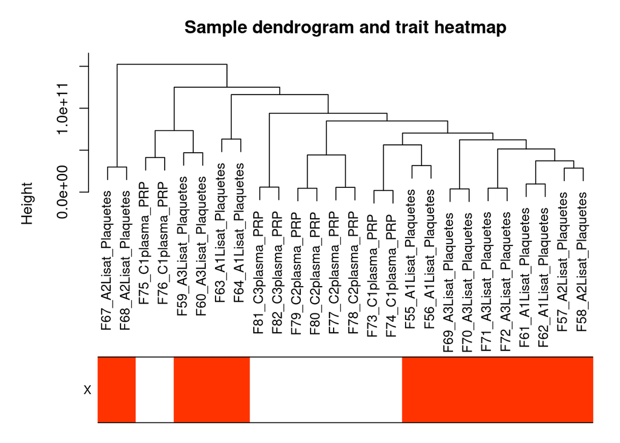

```r
# Re-cluster samples

sampleTree2_norm <- hclust(dist(datExpr0_norm), method = "average")
# Convert traits to a color representation: white means low, red means high, grey means missing entry

datTraits$Group_num <- datTraits$Group
datTraits$Group_num <- gsub("NaCl", 1, datTraits$Group_num)
datTraits$Group_num <- gsub("PRP", 0, datTraits$Group_num)
traitColors <- numbers2colors(as.numeric(datTraits$Group_num), signed = FALSE)
# Plot the sample dendrogram and the colors underneath.
plotDendroAndColors(sampleTree2_norm, traitColors,
  groupLabels = names(datTraits),
  main = "Sample dendrogram and trait heatmap"
)
```